# Statistica Medica — Corrado Lanera – Statistica Medica

[figure not shown]

[figure not shown]


# Statistica Medica

Distribuzioni di probabilità

Corrado Lanera

[Unità di Biostatistica, Epidemiologia e Salute Pubblica](https://www.unipd-ubep.it/), Università di Padova

12 novembre 2026

## Cosa faremo

Quello di cui ci interesseremo in questa lezione è di introdurre le principali distribuzioni di probabilità per eventi discreti, quali processi binomiali, utili per rappresentare il numero di successi per eventi dicotomici con una data probabilità p di esito positivo, e processi di Poisson utili a modellizzare il numero di eventi che è probabile osservare in un lasso di tempo stabilito. Inoltre ci occuperemo anche delle distribuzioni utili a descrivere eventi continui, con particolare attenzione alle distribuzioni normale e normale standard.

Per ciascuna, oltre a qualche rapido cenno teorico, vedremo come calcolare media e varianza, percentili (per le distribuzioni continue), oltre che qualche esempio concreto.

## Riconoscimenti

- Le diapositive proposte sono state prodotte a partire anche da materiale generato da/con le seguenti persone gravitanti attorno all’UBEP*:
  - Danila Azzolina
  - Dario Gregori
  - Giulia Lorenzoni
  - Honoria Ocagli
  - Ileana Baldi
  - Luca Vedovelli
  - Matteo Martinato
  - Paola Berchialla

* In ordine alfabetico.

> Un ringraziamento speciale a Cristiana Vettori e a Mariasole Rizzi per l’aiuto e il supporto logistico e amministrativo che mi è stato offerto, e ad Andrea Francavilla per avermi aiutato nella revisione del materiale.

## **Panoramica**

**Modello** probabilistico per variabili discrete: massa, valore atteso e varianza

Distribuzione **binomiale** (ovvero per variabili con due soli possibili esiti)

Distribuzione di **Poisson** (ovvero per variabili *conteggio*) e approssimazione della binomiale

**Modello** probabilistico per variabili continue: densità

Distribuzione **normale**, localizzazione, forma, simmetria, percentili, trasformazioni

## Modelli (probabilistici) **discreti**

- **Massa**
- **Valore atteso**
- **Varianza**

## Richiamo: Variabile casuale

Una variabile casuale è una quantità che assume **valori differenti** con **specifiche probabilità**

- una variabile casuale che assume un insieme discreto di valori con probabilità specificata è detta variabile casuale **discreta**
- una variabile casuale che assume un insieme continuo (e infinito) di valori, in modo che **gli intervalli** di tali valori abbiano probabilità specificata è detta variabile casuale continua

> Nota: una funzione di una variabile casuale **è** una variabile casuale

> Nota 2: **funzione**: una qualunque mappa/regola che associa **a ogni elemento** di un insieme (detto dominio della funzione) **un unico elemento** di un insieme (detto codominio della funzione).

## Modelli discreti

Obiettivo è determinare il modello probabilistico adatto ai dati che si vuole trattare, ovvero individuare eventi con la stessa struttura probabilistica

- distribuzione binomiale, in cui l’evento di interesse ha due possibili esiti
- distribuzione di Poisson, in cui l’evento di interesse è definito dal conteggio di eventi

## Modelli discreti: massa

- Definizione
- Esempio
- Distr. Cumulativa
- Esempio

Una funzione di (distribuzione di) massa di probabilità è una relazione matematica, o regola, che assegna **ad ogni possibile valore** $r$ di una variabile casuale discreta $X$ **la (sua) probabilità** $P(X=r)$.

Questa regola è definita per tutti i valori $r$ che hanno probabilità positiva.

> Importante: Valgono sempre:
> - $0\leq P(X=r) \leq 1$
> - $\sum P(X=r) = 1$

Un medico inizia a controllare lo stato ipertensivo di 4 suoi pazienti con farmaci antiipertensivi.

**Sia**: $X$ è il numero di pazienti complianti

**Allora**:

| r | P(X=r) |
| --- | --- |
| 0 | 0.008 |
| 1 | 0.076 |
| 2 | 0.265 |
| 3 | 0.411 |
| 4 | 0.240 |

La distribuzione cumulativa di una variabile casuale discreta è indicata come $F(x)$ ed è pari a $P(X\leq x)$

$$F(x) = P(X\leq x)$$

| r | P(X=r) | F(x) |
| --- | --- | --- |
| 0 | 0.008 | 0.008 |
| 1 | 0.076 | 0.084 |
| 2 | 0.265 | 0.349 |
| 3 | 0.411 | 0.760 |
| 4 | 0.240 | 1.000 |

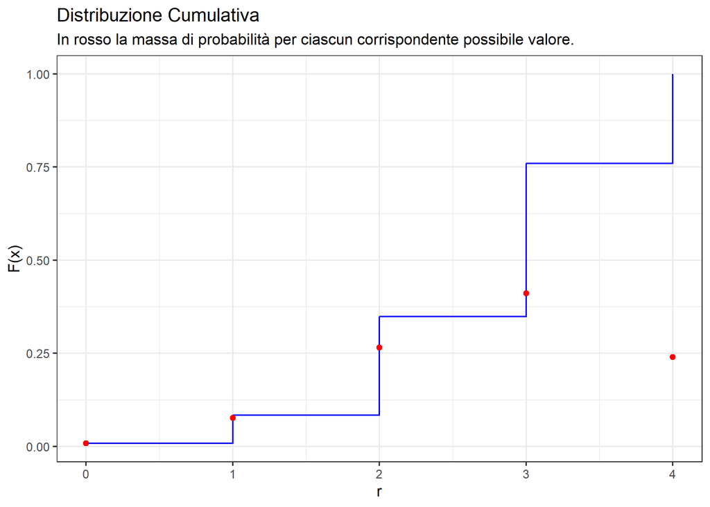

## Modelli discreti: valore atteso

- Definizione
- Esempio

Il valore atteso di una variabile casuale discreta è definito come

$$E(X)=\sum_{i\in I}x_iP(X=x_i)$$

dove $x_i$ sono i valori che la variabile casuale $X$ assume con probabilità positiva

Per la variabile $X =$ *pazienti complianti al controllo dell’ipertensione*

$$E(X)=0(0.008)+1(0.076)+2(0.265)+3(0.411)+4(0.240) = 2.799$$

| r | P(X=r) |
| --- | --- |
| 0 | 0.008 |
| 1 | 0.076 |
| 2 | 0.265 |
| 3 | 0.411 |
| 4 | 0.240 |

## Valore atteso: esempio

- Problema
- Soluzione

**Sia**: $X$ il **numero** di episodi di otiti **nei primi due anni di vita**, con la seguente rispettiva massa di probabilità:

| r | P(X=r) |
| --- | --- |
| 0 | 0.129 |
| 1 | 0.264 |
| 2 | 0.271 |
| 3 | 0.185 |
| 4 | 0.095 |
| 5 | 0.039 |
| 6 | 0.017 |

Determinare il numero atteso di episodi di otite nei primi due anni di vita

il numero atteso di episodi di otite nei primi due anni di vita è:

$$\begin{split}E(X) =\ &0(0.129)\ + \\&1(0.264)\ + \\& 2(0.271)\ + \\&3(0.185)\ + \\&4(0.095)\ + \\&5(0.039)\ + \\& 6(0.017) =\\& 2.038 \end{split}$$

## Modelli discreti: varianza

- Definizione
- Esempio

La varianza di una variabile casuale discreta $X$ è pari a

$$\mbox{var}(X)=\sum_r(x_r-\mu)^2P(X=x_r)=\sigma^2$$

vale anche

$$\sigma^2=E[(X-\mu)^2]=\left(\sum_r x_r^2P(X=x_r)\right)-\mu^2$$

La varianza della variabile casuale episodi di otite è pari a

$$0^2(0.129)+\ldots+6^2(0.017)-2.038^2=1.967$$

## Mappa: Modelli discreti

- Mappa
- Indice

```
%%{init: {"htmlLabels": false, "flowchart": {"padding": 12, "wrappingWidth": 320}, "themeVariables": {"fontFamily": "Arial, Helvetica, sans-serif"}}}%%
flowchart LR
  k_n_02_classi["Classi e medie ponderate · 02"]:::prev
  k_n_02_notazioni["Indici e sommatoria · 02"]:::prev
  k_n_02_tipi["Tipi di variabile · 02"]:::prev
  k_n_02_variabilita["Variabilità · 02"]:::prev
  k_n_03_operazioni["Operazioni fra eventi · 03"]:::prev
  k_n_03_probabilita["Probabilità · 03"]:::prev
  k_n_03_somma_prodotto["Somma, prodotto, indipendenza · 03"]:::prev
  n_variabile_casuale["Variabile casuale"]:::cur
  n_variabile_casuale_discreta["V.c. discreta"]:::cur
  n_variabile_casuale_continua["V.c. continua"]:::cur
  n_funzione_matematica["Funzione"]:::cur
  n_funzione_di_variabile_casuale["Funzione di v.c."]:::cur
  n_distribuzione_di_probabilita["Distribuzione di probabilità"]:::cur
  n_funzione_di_massa["Funzione di massa"]:::cur
  n_proprieta_della_funzione_di_massa["Proprietà della massa"]:::cur
  n_distribuzione_cumulativa["Cumulata F(x)"]:::cur
  n_valore_atteso["Valore atteso E(X)"]:::cur
  n_varianza_di_variabile_casuale["Varianza Var(X)"]:::cur
  k_n_02_classi --> n_valore_atteso
  k_n_02_notazioni --> n_distribuzione_cumulativa
  k_n_02_notazioni --> n_proprieta_della_funzione_di_massa
  k_n_02_notazioni --> n_valore_atteso
  k_n_02_tipi --> n_variabile_casuale
  k_n_02_variabilita --> n_varianza_di_variabile_casuale
  k_n_03_operazioni --> n_proprieta_della_funzione_di_massa
  k_n_03_probabilita --> n_variabile_casuale
  k_n_03_somma_prodotto --> n_proprieta_della_funzione_di_massa
  n_distribuzione_di_probabilita --> n_funzione_di_massa
  n_funzione_di_massa --> n_distribuzione_cumulativa
  n_funzione_di_massa --> n_proprieta_della_funzione_di_massa
  n_funzione_di_massa --> n_valore_atteso
  n_funzione_matematica --> n_funzione_di_massa
  n_funzione_matematica --> n_funzione_di_variabile_casuale
  n_valore_atteso --> n_varianza_di_variabile_casuale
  n_variabile_casuale --> n_distribuzione_di_probabilita
  n_variabile_casuale --> n_funzione_di_variabile_casuale
  n_variabile_casuale --> n_variabile_casuale_continua
  n_variabile_casuale --> n_variabile_casuale_discreta
  n_variabile_casuale_discreta --> n_funzione_di_massa
  classDef cur fill:#e6f0fa,stroke:#035AA6,color:#000000
  classDef prev fill:#f4f4f4,stroke:#9a9a9a,color:#555555,stroke-dasharray:4 3
  classDef opt fill:#ffffff,stroke:#035AA6,color:#555555,stroke-dasharray:2 2
```

Ogni freccia va da un concetto a quelli che lo usano. In grigio i concetti delle sezioni o dei deck precedenti (con il numero del deck).

- Variabile casuale
- V.c. discreta
- V.c. continua
- Funzione
- Funzione di v.c.
- Distribuzione di probabilità
- Funzione di massa
- Proprietà della massa
- Cumulata F(x)
- Valore atteso E(X)
- Varianza Var(X)

## Distribuzione **binomiale**

- Struttura e **distribuzione**
- Valore **atteso** e **varianza**
- Grafici

## Binomiale: struttura

Una variabile binomiale rappresenta la **quantità** di esiti **positivi** di un possibile esperimento con due soli risultati possibili (**dicotomico**), che possono avvenire con date **probabilità costanti** (complementari a 1).

Si caratterizza quindi da:

- $n$ prove **indipendenti**
- **due** possibili outcomes di ogni prova, successo o insuccesso
- la probabilità di successo, $p$ è costante in ogni prova (quella di insuccesso è pari a $1-p = q$)

Ed è utile per:

- valutare la probabilità di $k$ successi in $n$ prove

## Coefficiente binomiale

Il numero di combinazioni di $n$ oggetti presi $k$ alla volta è pari a

$$_nC_k=\binom{n}{k}=\frac{n(n-1)\ldots (n-k+1)}{k!}$$

moltiplicando numeratore e denominatore per $(n-k)!$ si ottiene

$$_nC_k=\binom{n}{k}=\frac{n!}{k!(n-k)!}$$

> Note:
- $n! := n\cdot (n-1)\cdot \cdots \cdot (2)\cdot 1$
- convenzione: $\binom{n}{0}=1$

## Distribuzione Binomiale: probabilità

la probabilità che $k$ successi avvengano in $n$ prove, con le rimanenti $n-k$ tutte insuccessi è pari a

$$p^k(1-p)^{n-k}$$

Tenendo conto che i $k$ successi si possono ottenere in $_nC_k$ modi diversi, si ha che

$$P(X=k)=\binom{n}{k}p^k(1-p)^{n-k}$$

che è la distribuzione di probabilità binomiale

## Distribuzione Binomiale

- Descrizione
- Esempio

La distribuzione binomiale, di parametri $n$ e $p$ si indica come

$$P(X=k)=\binom{n}{k}p^k(1-p)^{n-k} \:\:\:\: k=0,1,\ldots,n$$

Quale è la probabilità di ottenere 2 bambini maschi da 5 nati se la probabilità di un maschio è pari a 0.51, indipendente dal sesso dei bambini nati prima?

Si usa la distribuzione binomiale

$$P(X=2)=\binom{5}{2}0.51^2(0.49)^{5-2}=\frac{5 \times 4}{2 \times 1}0.51^2(0.49)^{5-2}=0.306$$

## Binomiale: Valore atteso e varianza

Sia $S$ la somma degli esiti delle singole prove, che indichiamo come variabili casuali $X_1,\ldots,X_n$. Ogni $X_i$ vale 1 (successo) con probabilità $p$ e 0 con probabilità $q$: $E(X_i) = 1\cdot p + 0\cdot q = p$ e $var(X_i) = (1-p)^2p + (0-p)^2q = pq$.

Per linearità

$$E(S) = E\left(\sum_{i=1}^n X_i\right) = \sum_{i=1}^nE(X_i) = \sum_{i=1}^np=np$$

Essendo le prove indipendenti, la **varianza di una somma di variabili indipendenti è la somma delle varianze**:

$$var(S) = var\left(\sum_{i=1}^n X_i\right) = \sum_{i=1}^nvar(X_i) = \sum_{i=1}^npq=npq$$

## 10 esperimenti: grafico

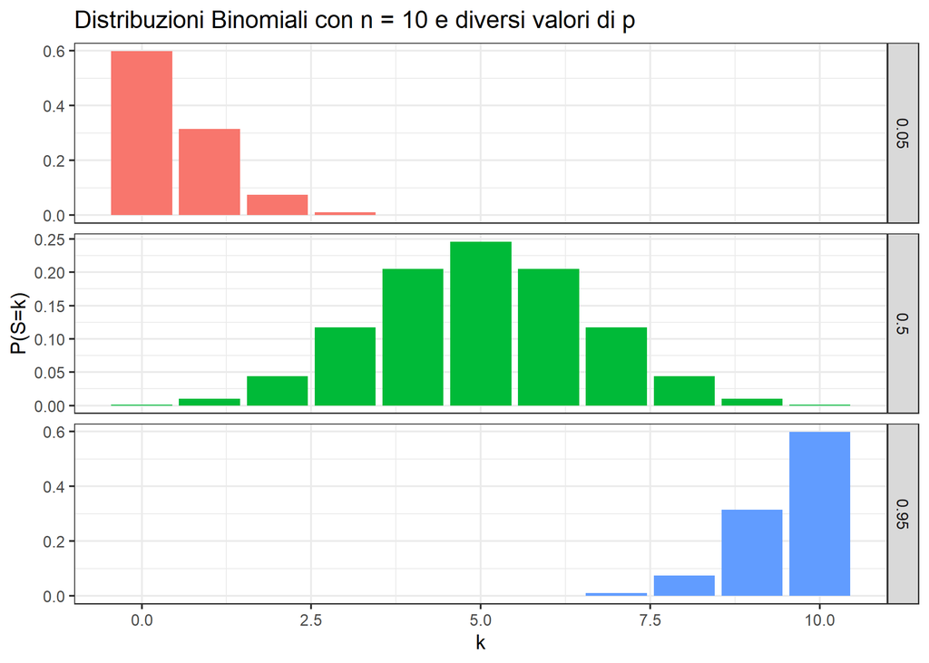

## Mappa: Binomiale

- Mappa
- Indice

```
%%{init: {"htmlLabels": false, "flowchart": {"padding": 12, "wrappingWidth": 320}, "themeVariables": {"fontFamily": "Arial, Helvetica, sans-serif"}}}%%
flowchart LR
  n_funzione_di_massa["Funzione di massa"]:::prev
  n_valore_atteso["Valore atteso E(X)"]:::prev
  n_varianza_di_variabile_casuale["Varianza Var(X)"]:::prev
  k_n_02_notazioni["Indici e sommatoria · 02"]:::prev
  k_n_02_tipi["Tipi di variabile · 02"]:::prev
  k_n_03_operazioni["Operazioni fra eventi · 03"]:::prev
  k_n_03_probabilita["Probabilità · 03"]:::prev
  k_n_03_somma_prodotto["Somma, prodotto, indipendenza · 03"]:::prev
  n_schema_binomiale["Schema binomiale"]:::cur
  n_fattoriale["Fattoriale n!"]:::cur
  n_coefficiente_binomiale["Coefficiente binomiale"]:::cur
  n_distribuzione_binomiale["Binomiale"]:::cur
  n_linearita_del_valore_atteso["Linearità di E(X)"]:::cur
  n_varianza_della_somma_di_indipendenti["Var della somma"]:::cur
  n_valore_atteso_e_varianza_della_binomiale["E e Var della binomiale"]:::cur
  n_forma_della_binomiale["Forma della binomiale"]:::cur
  k_n_02_notazioni --> n_linearita_del_valore_atteso
  k_n_02_tipi --> n_schema_binomiale
  k_n_03_operazioni --> n_schema_binomiale
  k_n_03_probabilita --> n_schema_binomiale
  k_n_03_somma_prodotto --> n_schema_binomiale
  k_n_03_somma_prodotto --> n_varianza_della_somma_di_indipendenti
  n_coefficiente_binomiale --> n_distribuzione_binomiale
  n_distribuzione_binomiale --> n_forma_della_binomiale
  n_distribuzione_binomiale --> n_valore_atteso_e_varianza_della_binomiale
  n_fattoriale --> n_coefficiente_binomiale
  n_funzione_di_massa --> n_distribuzione_binomiale
  n_linearita_del_valore_atteso --> n_valore_atteso_e_varianza_della_binomiale
  n_schema_binomiale --> n_distribuzione_binomiale
  n_valore_atteso --> n_linearita_del_valore_atteso
  n_varianza_della_somma_di_indipendenti --> n_valore_atteso_e_varianza_della_binomiale
  n_varianza_di_variabile_casuale --> n_varianza_della_somma_di_indipendenti
  classDef cur fill:#e6f0fa,stroke:#035AA6,color:#000000
  classDef prev fill:#f4f4f4,stroke:#9a9a9a,color:#555555,stroke-dasharray:4 3
  classDef opt fill:#ffffff,stroke:#035AA6,color:#555555,stroke-dasharray:2 2
```

Ogni freccia va da un concetto a quelli che lo usano. In grigio i concetti delle sezioni o dei deck precedenti (con il numero del deck).

- Schema binomiale
- Fattoriale n!
- Coefficiente binomiale
- Binomiale
- Linearità di E(X)
- Var della somma
- E e Var della binomiale
- Forma della binomiale

## Distribuzione di **Poisson**

- Struttura e **distribuzione**
- Valore **atteso** e **varianza**
- Grafici

## Poisson: struttura

Dato un intervallo di tempo $\Delta t$ molto piccolo, si ha che

- la probabilità di osservare un evento è direttamente proporzionale alla lunghezza dell’intervallo di tempo $\Delta t$, ovvero, per una qualche costante $\lambda$, abbiamo:

$$P(\mbox{1 evento})\sim \lambda\,\Delta t$$

- la probabilità di osservare $0$ eventi nell’intervallo $\Delta t$ è approssimativamente $1-\lambda\Delta t$
- la probabilità di osservare più di un evento nell’intervallo è sostanzialmente $0$
- Stazionarietà: il numero *atteso* di eventi per unità di tempo ($\lambda$) è lo stesso in tutto l’intervallo di tempo $t$ (no trend)
- Indipendenza: se si verifica un evento nell’intervallo di tempo considerato, questo non modifica la probabilità di osservarne un secondo nell’intervallo successivo.

## Distribuzione di Poisson: probabilità

La probabilità di osservare $k$ eventi in un periodo di tempo $t$ per una variabile aleatoria di Poisson di tasso $\lambda$ (parametro $\mu=\lambda t$) è pari a

$$P(X=k)=\frac{e^{-\mu}\mu^k}{k!} \:\:\:\: k=0,1,2,\ldots$$

dove $e$, pari a circa 2.71828, è la costante di Nepero.

## Distribuzione di Poisson

- Esempio
- Grafici

Si supponga che il numero di morti attribuite alla febbre tifoide in un anno sia una Poisson con parametro $\mu = 4.6$. Si cerca la probabilità su un periodo di 6 e 3 mesi che avvengono, per esempio, zero eventi o almeno 6

Dalla definizione si ha che $\mu = 4.6 \times 1$, quindi $\lambda = 4.6$.

Su 6 mesi si ha allora che $\mu=4.6 \times 0.5 = 2.3$

$$P(X=0) = e^{-2.3} = 0.1 \:\:\:\: P(X\geq6) = 1-P(X<6)=0.03$$

Su 3 mesi si ha allora che $\mu=4.6 \times 0.25 = 1.15$

$$P(X=0) = e^{-1.15} = 0.317 \:\:\:\: P(X\geq6) = 1-P(X<6)=0.001$$

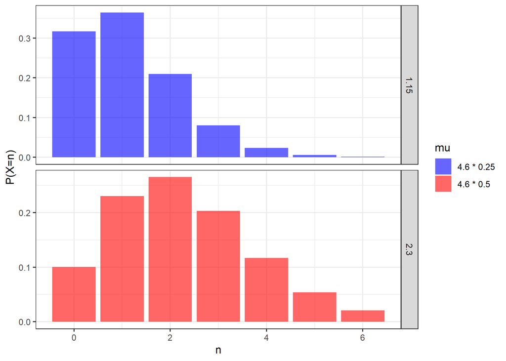

## Poisson: valore atteso e varianza

Per una distribuzione di Poisson con parametro $\mu$, la media e la varianza sono entrambe pari a $\mu$

## Poisson: cibo cancerogeno

In uno studio sul possibile effetto cancerogeno di EDB (etilene dibromide), osservando la mortalità di 161 operai bianchi, occupati presso due fabbriche, Texas e Michigan, 1940-1975

Si sono osservate 7 morti per cancro. In base ai dati di mortalità degli USA, si sarebbero attese in quel periodo 5.8 morti per cancro.

Si cerca quindi la probabilità di osservare almeno 7 morti secondo una Poisson di parametro $\mu=5.8$.

$$\begin{align}P(X \geq 7) &= 1 - P(X\leq 6)\\& = 1-\left[(e^{-5.8}5.8^0/0!)+ \ldots + (e^{-5.8}5.8^6/6!)\right]\\& = 0.362\end{align}$$

per cui le morti non sembrano in eccesso in questo gruppo di lavoratori.

## Poisson: Approssimazione

La distribuzione Binomiale con $n$ grande e $p$ piccolo può essere accuratamente approssimata da una distribuzione di Poisson con parametro $\mu=np$

La motivazione è data dalla maggiore semplicità computazionale della distribuzione di Poisson

Una regola approssimativa è di usare l’approssimazione quando $n\geq 100$ e $p\leq 0.01$

| k | bin | pois |
| --- | --- | --- |
| 0 | 0.3660323 | 0.3678794 |
| 1 | 0.3697296 | 0.3678794 |
| 2 | 0.1848648 | 0.1839397 |
| 3 | 0.0609992 | 0.0613132 |
| 4 | 0.0149417 | 0.0153283 |
| 5 | 0.0028978 | 0.0030657 |
| 6 | 0.0004635 | 0.0005109 |

## Poisson: tumore al seno

Si studia la suscettibilità genetica per il cancro alla mammella, trovando che 4 donne su 1000 tra i 40 e i 49 anni le cui madri hanno avuto un cancro al seno, lo sviluppano nell’anno successivo di vita.

In base a studi di popolazione, si pensa che in queste classi di età si dovrebbe avere circa 1 cancro al seno su 1000 donne.

Secondo la probabilità binomiale, con $n=1000$ e $p=1/1000$ si ha che
$$\begin{split}
P(X\geq 4)& = 1 - P(X\leq 3)\\& = 1- \left [\binom{1000}{0} (.001)^0(.999)^{1000}+\ldots+\binom{1000}{3} (.001)^3(.999)^{997} \right ]\\& = 0.019\end{split}$$

Secondo la probabilità di Poisson, con $\mu = 1$, si ha che

$$\begin{split}P(X\geq 4)& = 1- [e^{-1}1^0/0! + \ldots + e^{-1}1^3/3!]\\&= 1- 0.9810\\& = 0.019\end{split}$$

Un valore sufficientemente piccolo da far pensare ad una suscettibilità genetica.

## Sondaggio

Per me: [Discrete](https://app.wooclap.com/events/STATMEDDISCRETE/0)

Per voi:

[figure not shown]

bit.ly/statmed-sondaggio-discrete

## Mappa: Poisson

- Mappa
- Indice

```
%%{init: {"htmlLabels": false, "flowchart": {"padding": 12, "wrappingWidth": 320}, "themeVariables": {"fontFamily": "Arial, Helvetica, sans-serif"}}}%%
flowchart LR
  n_funzione_di_massa["Funzione di massa"]:::prev
  n_valore_atteso["Valore atteso E(X)"]:::prev
  n_varianza_di_variabile_casuale["Varianza Var(X)"]:::prev
  n_distribuzione_binomiale["Binomiale"]:::prev
  n_fattoriale["Fattoriale n!"]:::prev
  n_valore_atteso_e_varianza_della_binomiale["E e Var della binomiale"]:::prev
  k_n_02_notazioni["Indici e sommatoria · 02"]:::prev
  k_n_02_tipi["Tipi di variabile · 02"]:::prev
  k_n_03_operazioni["Operazioni fra eventi · 03"]:::prev
  k_n_03_probabilita["Probabilità · 03"]:::prev
  k_n_03_somma_prodotto["Somma, prodotto, indipendenza · 03"]:::prev
  n_tasso_di_evento["Tasso λ"]:::cur
  n_processo_di_poisson["Processo di Poisson"]:::cur
  n_costante_di_nepero["Costante e"]:::cur
  n_distribuzione_di_poisson["Poisson"]:::cur
  n_valore_atteso_e_varianza_della_poisson["E e Var della Poisson"]:::cur
  n_probabilita_di_coda["Probabilità di coda"]:::cur
  n_approssimazione_poisson_della_binomiale["Poisson per la binomiale"]:::cur
  n_probabilita_di_almeno_k["P(almeno k)"]:::cur
  k_n_02_notazioni --> n_probabilita_di_almeno_k
  k_n_02_tipi --> n_processo_di_poisson
  k_n_03_operazioni --> n_processo_di_poisson
  k_n_03_probabilita --> n_processo_di_poisson
  k_n_03_probabilita --> n_tasso_di_evento
  k_n_03_somma_prodotto --> n_processo_di_poisson
  n_costante_di_nepero --> n_distribuzione_di_poisson
  n_distribuzione_binomiale --> n_approssimazione_poisson_della_binomiale
  n_distribuzione_di_poisson --> n_approssimazione_poisson_della_binomiale
  n_distribuzione_di_poisson --> n_probabilita_di_almeno_k
  n_distribuzione_di_poisson --> n_valore_atteso_e_varianza_della_poisson
  n_fattoriale --> n_distribuzione_di_poisson
  n_funzione_di_massa --> n_distribuzione_di_poisson
  n_probabilita_di_almeno_k --> n_probabilita_di_coda
  n_processo_di_poisson --> n_distribuzione_di_poisson
  n_tasso_di_evento --> n_distribuzione_di_poisson
  n_valore_atteso --> n_valore_atteso_e_varianza_della_poisson
  n_valore_atteso_e_varianza_della_binomiale --> n_approssimazione_poisson_della_binomiale
  n_varianza_di_variabile_casuale --> n_valore_atteso_e_varianza_della_poisson
  classDef cur fill:#e6f0fa,stroke:#035AA6,color:#000000
  classDef prev fill:#f4f4f4,stroke:#9a9a9a,color:#555555,stroke-dasharray:4 3
  classDef opt fill:#ffffff,stroke:#035AA6,color:#555555,stroke-dasharray:2 2
```

Ogni freccia va da un concetto a quelli che lo usano. In grigio i concetti delle sezioni o dei deck precedenti (con il numero del deck).

- Tasso λ
- Processo di Poisson
- Costante e
- Poisson
- E e Var della Poisson
- Probabilità di coda
- Poisson per la binomiale
- P(almeno k)

## Break

Consigli:

- alzarsi
- sgranchirsi
- guardare *lontano* (rilassare gli occhi)
- bere
- andare in bagno

## Modello probabilistico per variabili **continue**

- **densità**

## Modelli **continui**

La distribuzione di densità di probabilità di una variabile casuale $X$ è una **curva** tale per cui:

- l’**area** sotto la curva, **compresa tra due punti** $a$ e $b$ è pari alla probabilità che la variabile casuale $X$ assuma valore nell’intervallo $(a,b)$
- l’**area totale** sotto la curva è pari ad 1.

## Esempi

- Ipertensione
- Trigliceridi

Densità di probabilità per la DBP in un uomo di età 35-44. A (90-95), B (95-100), C (> 100) sono rispettivamente Borderline, Moderatamente iperteso e Iperteso.

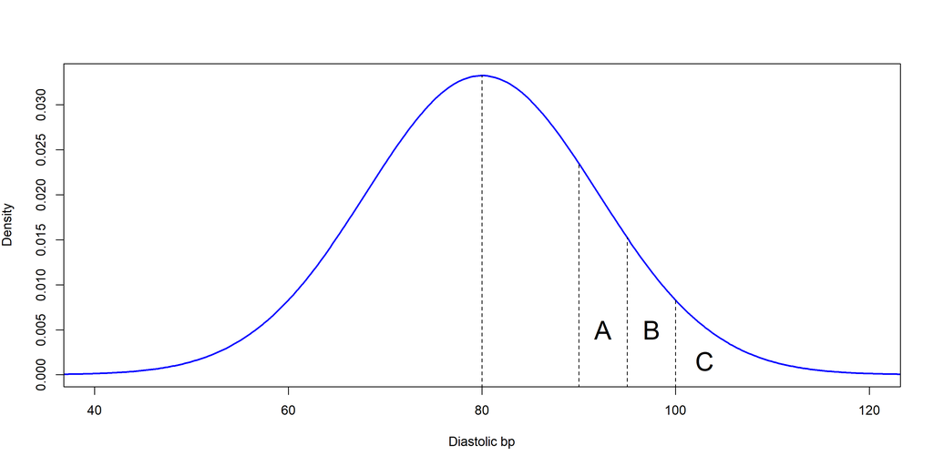

La distribuzione dei trigliceridi non è simmetrica: ha una coda lunga a destra

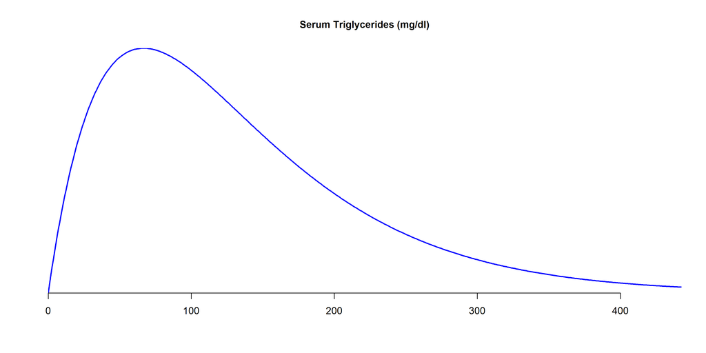

## Probabilità **cumulativa**

La distribuzione di probabilità cumulativa di una variabile casuale $X$ valutata in un punto $a$ è pari alla probabilità che $X$ prenda valori $\leq a$.

Rappresenta l’area sotto la curva alla sinistra di $a$

#### Esempio

La distribuzione cumulativa del peso alla nascita (once) valutata in 88 once è pari a $P(X\leq 88)$ ed è pari all’area sotto la curva a sinistra di 88 once. Questo valore è usato come limite per possibili outcomes sfavorevoli nel primo anno di vita

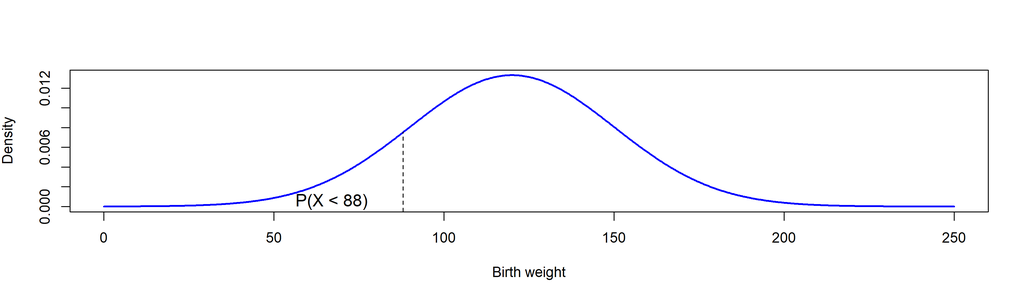

## Valore atteso e varianza

L’**atteso** $E(X)$ (o $\mu$) è la media dei valori di $X$: somma pesata nel discreto, integrale nel continuo

$$E(X)=\int_{-\infty}^{\infty} x f(x)\,dx.$$

La **varianza** $\text{Var}(X)$ (o $\sigma^2$) è la media dello scarto quadratico dall’atteso:

$$\text{Var}(X)=\int_{-\infty}^{\infty} (x-E[X])^2 f(x)\,dx.$$

La **deviazione standard** è $\sqrt{\text{Var}(X)}$.

La **mediana** divide in due la distribuzione, ovvero $P(X\leq m)=\frac{50}{100}=\frac{1}{2}$.

I **percentili** generalizzano quest’idea, ovvero $P(X\leq p_k)=\frac{k}{100}$.

## Parametri vs Statistiche

| Simbolo | Nome | Popolazione | Campione |
| --- | --- | --- | --- |
| $\mu$ | Valore atteso / media | centro teorico | $\bar{x}$ = media campionaria |
| $\sigma^2$ | Varianza | variabilità teorica | $s^2$ = varianza campionaria |
| $\sigma$ | Deviazione standard | disp. media teorica | $s$ = dev. std. campionaria |

- **Parametri** ($\mu$, $\sigma^2$, $\sigma$): grandezze vere della popolazione (in genere ignote).
- **Statistiche** ($\bar{x}$, $s^2$, $s$): stime calcolate dai dati campionari.

## Sondaggio

Per me: [Continue](https://app.wooclap.com/events/STAMEDCONTINUE/0)

Per voi:

[figure not shown]

bit.ly/statmed-sondaggio-continue

## Mappa: Variabili continue

- Mappa
- Indice

```
%%{init: {"htmlLabels": false, "flowchart": {"padding": 12, "wrappingWidth": 320}, "themeVariables": {"fontFamily": "Arial, Helvetica, sans-serif"}}}%%
flowchart LR
  n_distribuzione_cumulativa["Cumulata F(x)"]:::prev
  n_distribuzione_di_probabilita["Distribuzione di probabilità"]:::prev
  n_funzione_matematica["Funzione"]:::prev
  n_proprieta_della_funzione_di_massa["Proprietà della massa"]:::prev
  n_valore_atteso["Valore atteso E(X)"]:::prev
  n_variabile_casuale_continua["V.c. continua"]:::prev
  n_varianza_di_variabile_casuale["Varianza Var(X)"]:::prev
  k_n_02_centralita["Centralità · 02"]:::prev
  k_n_02_percentili["Percentili e quartili · 02"]:::prev
  k_n_02_unita["Unità, variabili, tabelle · 02"]:::prev
  k_n_02_variabilita["Variabilità · 02"]:::prev
  k_n_03_probabilita["Probabilità · 03"]:::prev
  n_funzione_di_densita["Densità"]:::cur
  n_integrale["Integrale"]:::cur
  n_valore_atteso_e_varianza_continui["E e Var (continue)"]:::cur
  n_mediana_di_distribuzione["Mediana di distribuzione"]:::cur
  n_percentile_di_distribuzione["Percentile di distribuzione"]:::cur
  n_parametro["Parametro"]:::cur
  n_statistica_campionaria["Statistica campionaria"]:::cur
  k_n_02_centralita --> n_mediana_di_distribuzione
  k_n_02_centralita --> n_statistica_campionaria
  k_n_02_percentili --> n_percentile_di_distribuzione
  k_n_02_unita --> n_statistica_campionaria
  k_n_02_variabilita --> n_parametro
  k_n_02_variabilita --> n_statistica_campionaria
  k_n_02_variabilita --> n_valore_atteso_e_varianza_continui
  k_n_03_probabilita --> n_funzione_di_densita
  n_distribuzione_cumulativa --> n_mediana_di_distribuzione
  n_distribuzione_di_probabilita --> n_funzione_di_densita
  n_funzione_di_densita --> n_mediana_di_distribuzione
  n_funzione_di_densita --> n_valore_atteso_e_varianza_continui
  n_funzione_matematica --> n_funzione_di_densita
  n_integrale --> n_valore_atteso_e_varianza_continui
  n_mediana_di_distribuzione --> n_percentile_di_distribuzione
  n_proprieta_della_funzione_di_massa --> n_funzione_di_densita
  n_valore_atteso --> n_parametro
  n_valore_atteso --> n_valore_atteso_e_varianza_continui
  n_variabile_casuale_continua --> n_funzione_di_densita
  n_varianza_di_variabile_casuale --> n_parametro
  n_varianza_di_variabile_casuale --> n_valore_atteso_e_varianza_continui
  classDef cur fill:#e6f0fa,stroke:#035AA6,color:#000000
  classDef prev fill:#f4f4f4,stroke:#9a9a9a,color:#555555,stroke-dasharray:4 3
  classDef opt fill:#ffffff,stroke:#035AA6,color:#555555,stroke-dasharray:2 2
```

Ogni freccia va da un concetto a quelli che lo usano. In grigio i concetti delle sezioni o dei deck precedenti (con il numero del deck).

- Densità
- Integrale
- E e Var (continue)
- Mediana di distribuzione
- Percentile di distribuzione
- Parametro
- Statistica campionaria

## Distribuzione **normale**

- **localizzazione**
- **forma**
- **simmetria**
- **percentili**
- **trasformazioni**

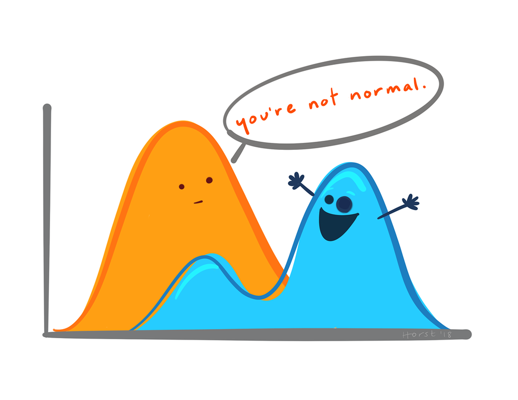

## Distribuzione Normale: definizione

$$f(x) = \frac{1}{\sigma\sqrt{2\pi}}e^{-\frac{1}{2\sigma^2}(x-\mu)^2} \:\:\:\: -\infty<x<\infty$$

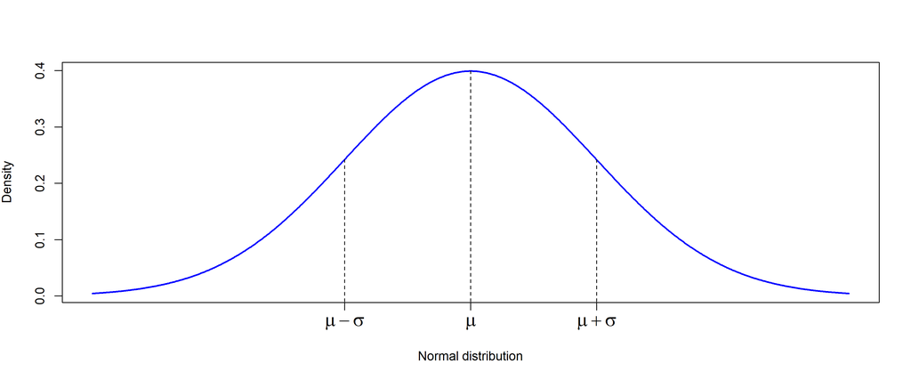

La distribuzione normale è definita dalla sua distribuzione di densità di probabilità:

## Distribuzione Normale: parametri

$$f(x) = \frac{1}{\sigma\sqrt{2\pi}}e^{-\frac{1}{2\sigma^2}(x-\mu)^2} \:\:\:\: -\infty<x<\infty$$

Una distribuzione normale con media $\mu$ e varianza $\sigma^2$ si indica come $N(\mu, \sigma^2)$.

I suoi parametri modellano la locazione e la forma della distribuzione

## Distribuzione Normale: localizzazione

$$f(x) = \frac{1}{\sigma\sqrt{2\pi}}e^{-\frac{1}{2\sigma^2}(x-\mu)^2} \:\:\:\: -\infty<x<\infty$$

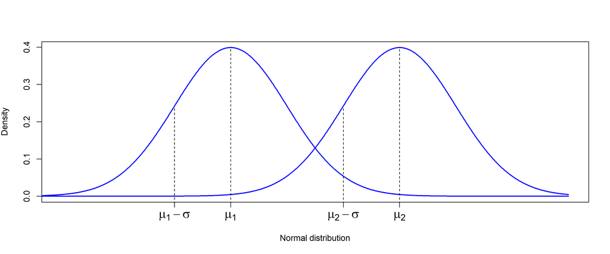

Cambiando $\mu$, a parità di $\sigma$, la curva si **sposta** lungo l’asse: la forma resta la stessa.

## Distribuzione Normale: forma

$$f(x) = \frac{1}{\sigma\sqrt{2\pi}}e^{-\frac{1}{2\sigma^2}(x-\mu)^2} \:\:\:\: -\infty<x<\infty$$

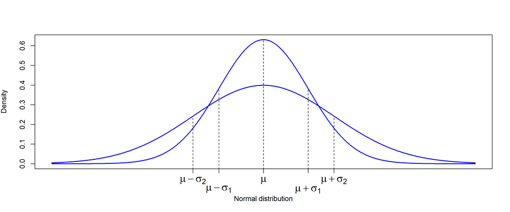

Aumentando $\sigma$, a parità di $\mu$, la curva resta centrata in $\mu$ e diventa **più larga e più bassa**: l’area sotto la curva vale sempre 1.

## Distribuzione Normale Standard

Una distribuzione normale con media 0 e varianza 1 si indica come distribuzione normale standard $N(0,1)$ (o anche solo **Standard**)

$$f(x) = \frac{1}{\sqrt{2\pi}}e^{-\frac{1}{2}x^2} \:\:\:\: -\infty<x<\infty$$

> Memo: distribuzione Normale (generale):

> $$f(x) = \frac{1}{\sigma\sqrt{2\pi}}e^{-\frac{1}{2\sigma^2}(x-\mu)^2} \:\:\:\: -\infty<x<\infty$$

## Distribuzione Standard: simmetria

La distribuzione $N(0,1)$ è simmetrica intorno allo $0$, avendo $f(x) = f(-x)$

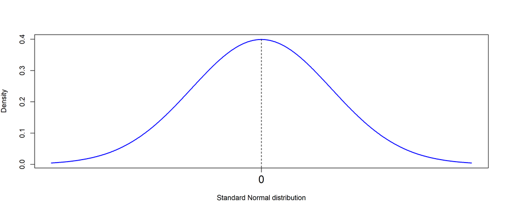

## Distribuzione Standard: valori notevoli

- circa il 68% dell’area cade tra $-1$ e $1$
- circa il 95% dell’area cade tra circa $-2$ e $2$
- circa il 99% dell’area cade tra circa $-2.5$ e $2.5$

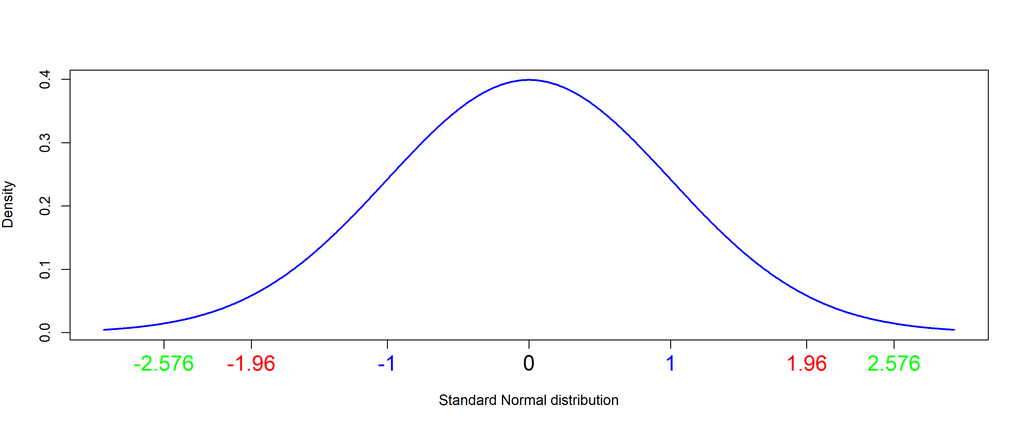

> (Spoiler: percentili?…)

## Distribuzione Standard: cumulativa

La distribuzione cumulativa per $N(0, 1)$ è indicata da $\Phi(x) = P(Z\leq x)$

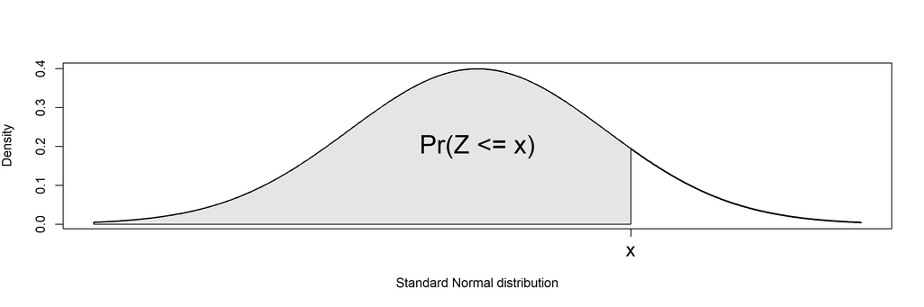

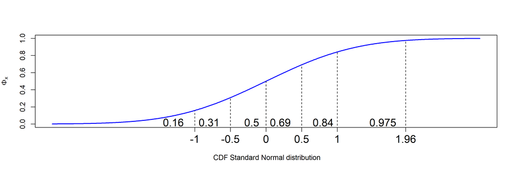

## Distribuzione cumulativa Standard: applicazione

La cumulata $\Phi(x)$ può aiutare a calcolare le probabilità di una $N(0,1)$

Trovare (non *calcolare*) $P(Z \leq 1.96)$ e $P(Z \leq 1)$… cerco i valori nelle tavole:

$$\Phi(1.96) = 0.975$$

$$\Phi(1) = 0.8413$$

## Distribuzione Standard: strategia simmetrica

Per la simmetria si ha che

$$\Phi(-x)=P(Z\leq -x) = P(Z \geq x) = 1-P(Z\leq x) = 1-\Phi(x)$$

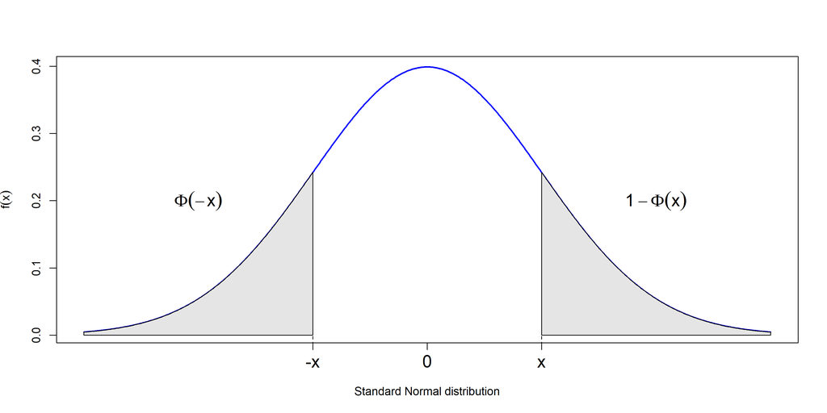

## Strategia: esempio

Per calcolare $P(Z \leq -1.96)$ si ha che:

$$\Phi(-1.96) = P(Z\geq 1.96) = 1 - P(Z\leq 1.96) = 0.0250$$

## Normale Standard: FVC

La **capacità vitale forzata** (FVC) è una misura di funzionalità polmonare ed è misurata dalla quantità d’aria che una persona riesce ad espellere in 6 secondi.

Si fa riferimento ad una FVC standard per ovviare a elementi di confondimento (età, fumo, …).

Un bambino è considerato a rischio se ha una FVC inferiore alla media di più di 1.5 deviazioni standard.

Allora, **sotto l’ipotesi che lo scarto dalla FVC si distribuisca come una Normale Standard**, possiamo calcolare con quale probabilità possiamo trovare valori più estremi, ovvero:

$$P(Z \leq -1.5) = P(Z \geq 1.5) = 0.0668$$

Ovvero, possiamo ipotizzare che circa il 7% dei bambini siano in condizioni polmonari compromesse

- Problema
- Soluzione

Di prassi, un bambino sarà considerato con un sistema polmonare *normale* se presenta una FVC entro un range di 1.5 deviazioni standard dalla media standardizzata.

> Con quale probabilità potremmo incontrare bambini con un sistema polmonare *normale*?

$$\begin{split}P(-1.5 \leq Z \leq 1.5)& = 1 - (P(Z \leq -1.5) + P(Z \geq 1.5))\\& = 1 - 2*P(Z \leq -1.5)\\& = 1 - 2 * 0.0668\\& = 0.8664\end{split}$$

## Distribuzione Normale: percentili

Il $100p$-esimo percentile di una normale standard è indicato con $z_p$ ed è definito dalla relazione

$$P(Z < z_p)=p$$

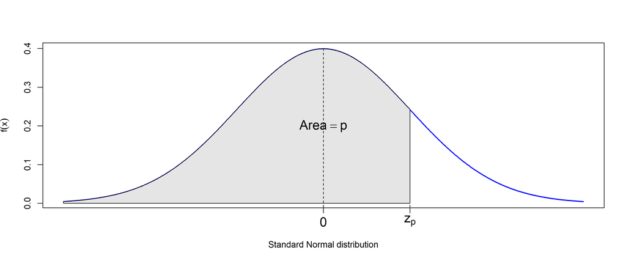

## Percentili Standard: calcolo

Per trovare $z_p$ si deve trovare l’area $p$ e quindi trovare il valore che corrisponde a tale area.

Se $p < 0.5$ ($z_p < 0$) è utile usare la simmetria della distribuzione per ottenere $z_p = -z_{1-p}$, dove $1-p > 0.5$ ($z_{1-p} > 0$) può essere spesso ottenuto dai valori comuni/noti come per esempio:

$$z_{.975}=1.96 \:\:\:\: z_{.95}=1.645 \:\:\:\: z_{.5}=0 \:\:\:\: z_{.025}=-1.96$$

## Normale Standard: trasformazioni

- Analiticamente
- Graficamente

**Se**:

- $X \sim N(\mu, \sigma^2)$
- $Z = \frac{X-\mu}{\sigma}$

**Allora**: $Z \sim N(0,1)$

**E vale dunque**:

$$\begin{split}P(a \leq X \leq b)& = P \left ( \frac{a-\mu}{\sigma} \leq Z \leq \frac{b-\mu}{\sigma}\right )\\& = P \left (Z \leq \frac{b-\mu}{\sigma}\right ) - P \left (Z \leq \frac{a-\mu}{\sigma}\right )\\& = \Phi[(b-\mu)/\sigma]-\Phi[(a-\mu)/\sigma]\end{split}$$

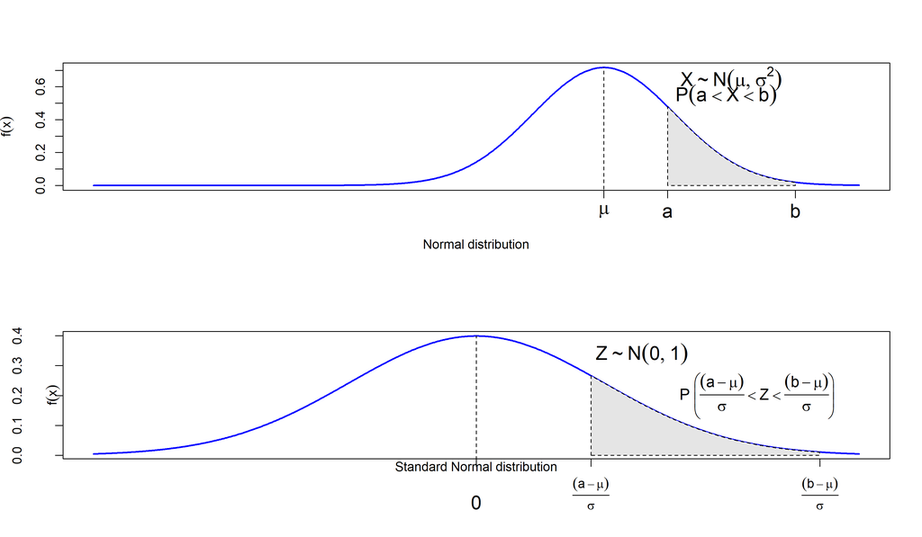

## Caso di studio: ipertensione

- Problema
- Soluzione

Una persona borderline per ipertensione è definita come una DBP compresa tra 90 e 95 mm Hg. Nei maschi tra i 35 ed i 44 anni la DBP è distribuita normalmente con media 80 e varianza 144 Si vuole la probabilità di essere borderline per un maschio in quella classe di età

$$\begin{split}P(90 \leq X \leq 95)& = P \left ( \frac{90-80}{12} \leq Z \leq \frac{95-80}{12}\right )\\& = \Phi[1.25]-\Phi[0.83]\\& = 0.8944-0.7967\\& = 0.098\end{split}$$

## Caso di studio: diametri del tronco

- Problema
- Soluzione

Si supponga che i diametri di alcuni arbusti siano distribuiti normalmente con media 8 cm e deviazione standard 2 cm.

La probabilità per un arbusto di avere un diametro eccezionalmente grande ($> 12 cm$) è pari a?

$$\begin{split}P(X > 12)& = 1 - P \left ( Z < \frac{12-8}{2}\right )\\& = 1-\Phi[2]\\& = 1-0.977\\& = 0.023
\end{split}$$

## Caso di studio: flusso ematico cerebrale

- Problema
- Soluzione

Nella popolazione generale il flusso ematico cerebrale (CBF) è distribuito normalmente con media 75 e deviazione standard 17. Un paziente è definito a rischio di stroke se ha una CBF $<$ 40.

La probabilità di essere a rischio è pari a?

$$\begin{split}P(X < 40)& = P \left ( Z < \frac{40-75}{17}\right )\\&= \Phi[-2.059]\\& = 1-\Phi[2.059]\\& = 1-0.98\\& = 0.02\end{split}$$

## Caso di studio: glaucoma

- Problema
- Soluzione
- grafico

Il glaucoma è una malattia che si presenta con una pressione intraoculare eccessiva. Nella popolazione generale, la pressione intraoculare è normale con media 16 mm Hg e deviazione standard 3 mm Hg.

Se il range di normalità è tra i 12 ed i 20 mm Hg, la probabilità di essere normali è pari a?

$$\begin{split}P(12 < X < 20)& = P \left (\frac{12-16}{3}< Z < \frac{20-16}{3}\right )\\& = \Phi[4/3]-\Phi[-4/3]\\& = \Phi[1.33]-(1-\Phi[1.33])\\& = 0.816\end{split}$$

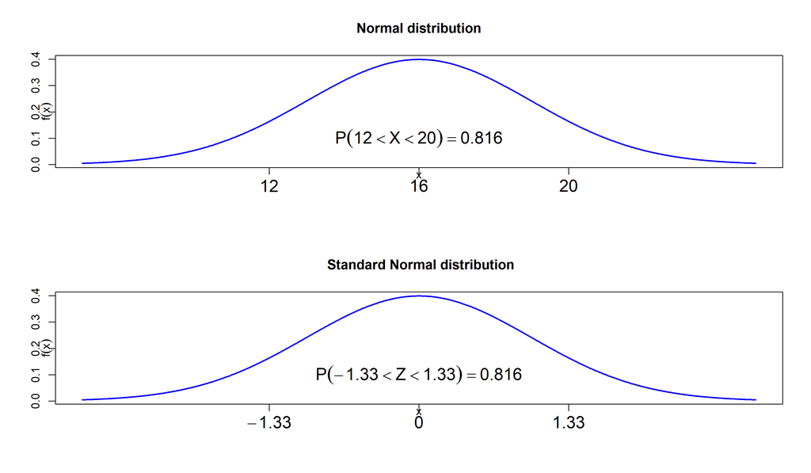

## Sondaggio

Per me: [Normale](https://app.wooclap.com/events/STATMEDNORMALE/0)

Per voi:

[figure not shown]

bit.ly/statmed-sondaggio-normale

## Mappa: Normale

- Mappa
- Indice

```
%%{init: {"htmlLabels": false, "flowchart": {"padding": 12, "wrappingWidth": 320}, "themeVariables": {"fontFamily": "Arial, Helvetica, sans-serif"}}}%%
flowchart LR
  n_distribuzione_cumulativa["Cumulata F(x)"]:::prev
  n_funzione_di_variabile_casuale["Funzione di v.c."]:::prev
  n_costante_di_nepero["Costante e"]:::prev
  n_funzione_di_densita["Densità"]:::prev
  n_parametro["Parametro"]:::prev
  n_percentile_di_distribuzione["Percentile di distribuzione"]:::prev
  n_valore_atteso_e_varianza_continui["E e Var (continue)"]:::prev
  k_n_03_operazioni["Operazioni fra eventi · 03"]:::prev
  k_n_03_somma_prodotto["Somma, prodotto, indipendenza · 03"]:::prev
  n_distribuzione_normale["Normale"]:::cur
  n_parametri_della_normale["Parametri μ e σ"]:::cur
  n_localizzazione_della_normale["Effetto di μ"]:::cur
  n_forma_della_normale["Effetto di σ"]:::cur
  n_normale_standardizzata["Normale standard"]:::cur
  n_simmetria_della_normale["Simmetria della normale"]:::cur
  n_regola_empirica_68_95_99["68-95-99%"]:::cur
  n_cumulata_normale_standard["Cumulata Φ"]:::cur
  n_tavole_della_normale["Tavole della normale"]:::cur
  n_simmetria_della_cumulata["Φ(−x) = 1 − Φ(x)"]:::cur
  n_percentile_della_normale_standard["Percentili di Z"]:::cur
  n_calcolo_dei_percentili_della_normale["Calcolo dei percentili"]:::cur
  n_standardizzazione["Standardizzazione"]:::cur
  k_n_03_operazioni --> n_simmetria_della_cumulata
  k_n_03_somma_prodotto --> n_standardizzazione
  n_costante_di_nepero --> n_distribuzione_normale
  n_cumulata_normale_standard --> n_percentile_della_normale_standard
  n_cumulata_normale_standard --> n_standardizzazione
  n_cumulata_normale_standard --> n_tavole_della_normale
  n_distribuzione_cumulativa --> n_cumulata_normale_standard
  n_distribuzione_normale --> n_normale_standardizzata
  n_distribuzione_normale --> n_parametri_della_normale
  n_funzione_di_densita --> n_distribuzione_normale
  n_funzione_di_variabile_casuale --> n_standardizzazione
  n_normale_standardizzata --> n_cumulata_normale_standard
  n_normale_standardizzata --> n_regola_empirica_68_95_99
  n_normale_standardizzata --> n_simmetria_della_normale
  n_parametri_della_normale --> n_forma_della_normale
  n_parametri_della_normale --> n_localizzazione_della_normale
  n_parametri_della_normale --> n_standardizzazione
  n_parametro --> n_parametri_della_normale
  n_percentile_della_normale_standard --> n_calcolo_dei_percentili_della_normale
  n_percentile_di_distribuzione --> n_percentile_della_normale_standard
  n_regola_empirica_68_95_99 --> n_calcolo_dei_percentili_della_normale
  n_simmetria_della_normale --> n_calcolo_dei_percentili_della_normale
  n_simmetria_della_normale --> n_simmetria_della_cumulata
  n_tavole_della_normale --> n_calcolo_dei_percentili_della_normale
  n_tavole_della_normale --> n_simmetria_della_cumulata
  n_valore_atteso_e_varianza_continui --> n_distribuzione_normale
  classDef cur fill:#e6f0fa,stroke:#035AA6,color:#000000
  classDef prev fill:#f4f4f4,stroke:#9a9a9a,color:#555555,stroke-dasharray:4 3
  classDef opt fill:#ffffff,stroke:#035AA6,color:#555555,stroke-dasharray:2 2
```

Ogni freccia va da un concetto a quelli che lo usano. In grigio i concetti delle sezioni o dei deck precedenti (con il numero del deck).

- Normale
- Parametri μ e σ
- Effetto di μ
- Effetto di σ
- Normale standard
- Simmetria della normale
- 68-95-99%
- Cumulata Φ
- Tavole della normale
- Φ(−x) = 1 − Φ(x)
- Percentili di Z
- Calcolo dei percentili
- Standardizzazione

## Mappa: tutte le sezioni

- Mappa
- Blocchi

```
%%{init: {"htmlLabels": false, "flowchart": {"padding": 12, "wrappingWidth": 320}, "themeVariables": {"fontFamily": "Arial, Helvetica, sans-serif"}}}%%
flowchart LR
  k_n_02_centralita["Centralità · 02"]:::prev
  k_n_02_classi["Classi e medie ponderate · 02"]:::prev
  k_n_02_notazioni["Indici e sommatoria · 02"]:::prev
  k_n_02_percentili["Percentili e quartili · 02"]:::prev
  k_n_02_tipi["Tipi di variabile · 02"]:::prev
  k_n_02_unita["Unità, variabili, tabelle · 02"]:::prev
  k_n_02_variabilita["Variabilità · 02"]:::prev
  k_n_03_operazioni["Operazioni fra eventi · 03"]:::prev
  k_n_03_probabilita["Probabilità · 03"]:::prev
  k_n_03_somma_prodotto["Somma, prodotto, indipendenza · 03"]:::prev
  k_n_04_vc["Variabili casuali (5)"]:::cur
  k_n_04_massa["Massa e cumulata (4)"]:::cur
  k_n_04_momenti["Valore atteso e varianza (4)"]:::cur
  k_n_04_binomiale["Binomiale (6)"]:::cur
  k_n_04_poisson["Poisson (8)"]:::cur
  k_n_04_densita["Densità (5)"]:::cur
  k_n_04_parametri["Parametri e statistiche (2)"]:::cur
  k_n_04_normale["Normale (7)"]:::cur
  k_n_04_tavole["Tavole e standardizzazione (6)"]:::cur
  k_n_02_centralita --> k_n_04_densita
  k_n_02_centralita --> k_n_04_parametri
  k_n_02_classi --> k_n_04_momenti
  k_n_02_notazioni --> k_n_04_massa
  k_n_02_percentili --> k_n_04_densita
  k_n_02_tipi --> k_n_04_vc
  k_n_02_unita --> k_n_04_parametri
  k_n_02_variabilita --> k_n_04_momenti
  k_n_03_operazioni --> k_n_04_massa
  k_n_03_probabilita --> k_n_04_vc
  k_n_03_somma_prodotto --> k_n_04_massa
  k_n_04_binomiale --> k_n_04_poisson
  k_n_04_densita --> k_n_04_normale
  k_n_04_massa --> k_n_04_momenti
  k_n_04_momenti --> k_n_04_binomiale
  k_n_04_momenti --> k_n_04_densita
  k_n_04_momenti --> k_n_04_parametri
  k_n_04_normale --> k_n_04_tavole
  k_n_04_parametri --> k_n_04_normale
  k_n_04_poisson --> k_n_04_normale
  k_n_04_vc --> k_n_04_massa
  classDef cur fill:#e6f0fa,stroke:#035AA6,color:#000000
  classDef prev fill:#f4f4f4,stroke:#9a9a9a,color:#555555,stroke-dasharray:4 3
  classDef opt fill:#ffffff,stroke:#035AA6,color:#555555,stroke-dasharray:2 2
```

Ogni freccia va da un concetto a quelli che lo usano. Ogni riquadro è un blocco di concetti che si usano insieme; fra parentesi quanti sono.

- **Variabili casuali**: Variabile casuale, V.c. discreta, V.c. continua, Funzione, Funzione di v.c.
- **Massa e cumulata**: Distribuzione di probabilità, Funzione di massa, Proprietà della massa, Cumulata F(x)
- **Valore atteso e varianza**: Valore atteso E(X), Varianza Var(X), Linearità di E(X), Var della somma
- **Binomiale**: Schema binomiale, Fattoriale n!, Coefficiente binomiale, Binomiale, E e Var della binomiale, Forma della binomiale
- **Poisson**: Tasso λ, Processo di Poisson, Costante e, Poisson, P(almeno k), E e Var della Poisson, Probabilità di coda, Poisson per la binomiale
- **Densità**: Densità, Integrale, E e Var (continue), Mediana di distribuzione, Percentile di distribuzione
- **Parametri e statistiche**: Parametro, Statistica campionaria
- **Normale**: Normale, Parametri μ e σ, Effetto di μ, Effetto di σ, Normale standard, Simmetria della normale, 68-95-99%
- **Tavole e standardizzazione**: Cumulata Φ, Tavole della normale, Φ(−x) = 1 − Φ(x), Percentili di Z, Calcolo dei percentili, Standardizzazione

## Risorse utili

- *Fundamentals of Biostatistics* (8ª ed., Cengage, 2016) di **Bernard Rosner**, suggeriti i capitoli 4 e 5.
- [Perché n − 1 nella formula della deviazione standard campionaria?](http://rdossena.altervista.org/Articoli/Book-Perch%E9%20n-1.pdf) di [Riccardo Dossena](http://rdossena.altervista.org) Traduzione dell’articolo **Book, S.A.**: *Why n − 1 in the formula for the sample standard deviation?*, The Two-Year College Mathematics Journal 10(5), 330–333 (1979

## Fonti

- «Poisson: cibo cancerogeno»: Ott MG, Scharnweber HC, Langner RR. [Mortality experience of 161 employees exposed to ethylene dibromide in two production units](https://doi.org/10.1136/oem.37.2.163). *British Journal of Industrial Medicine* 1980;37(2):163-168.
- Illustrazione «not normal»: [Allison Horst](https://allisonhorst.com).

*Mathematical conventions are just that, conventions. They differ by field of mathematics. Don’t ask us why **matrix rows** **are numbered down** but **graphs** **are numbered up** the **y axis**, nor why **x comes before y** but **row before column**. But the matrix layout has always seemed illogical to me.*

—Brian D. Ripley  
08/2004 - R-help

### **Grazie** per l’attenzione!

… e buona settimana.

Diapositive: bit.ly/cl-statmed

[**www.unipd-ubep.it**](https://www.unipd-ubep.it/) | **Corrado.Lanera@ubep.unipd.it**

**@CorradoLanera** | [**bit.ly/statmed-cl-ricevimento**](https://bit.ly/statmed-cl-ricevimento)